# Image Compression Web Site

## PCA Image Compression Function

This function takes a $n \times p$ matrix image and a value of k as inputs, and returns:

- The rank k PCA approximation of the image
- The Frobenius norm error

```r
# PCA funtion
compress_image_eigen <- function(img_matrix, k) {

  # Compute V = X'X
  V <- t(img_matrix) %*% img_matrix

  # Eigendecomposition of V
  eig <- eigen(V)
  U <- eig$vectors

  # Compute PC scores Z = XU
  Z <- img_matrix %*% U

  # The rank k PCA approximation
  Xk <- Z[, 1:k] %*% t(U[, 1:k])

  # Frobenius norm error
  error <- norm(img_matrix - Xk, type = "F")

 return(list(approx = Xk, error = error))
}
```

## 1. Image 1 Analysis

### 1.1 Load Image

```r
library(readr)

# Read the CSV file into a data frame
x1 <- read_csv("image1.csv")
# Convert data frame into a matrix
x1 <- data.matrix(x1)
```

### 1.2 Original Image

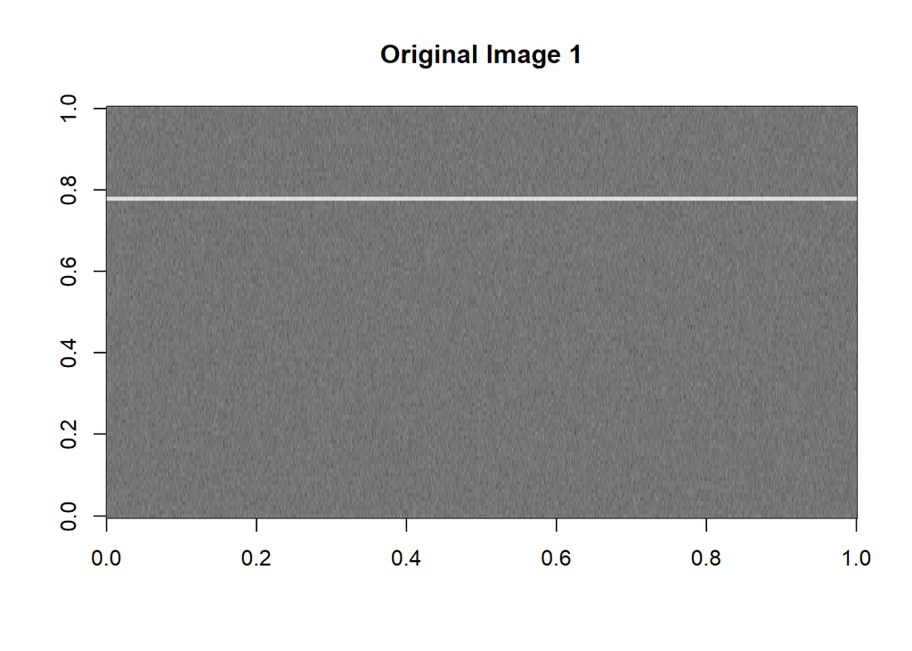

```r
image(x1, col = gray.colors(256), main = "Original Image 1")
```

### 1.3 PCA Approximations (k = 1 to 10)

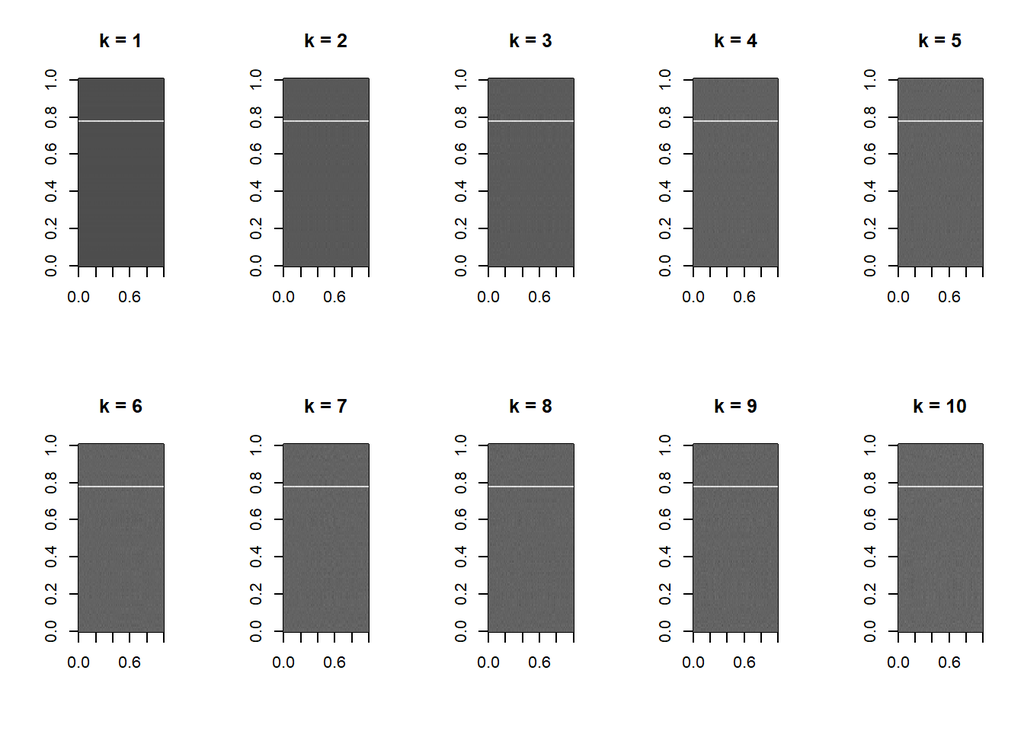

```r
par(mfrow = c(2,5))
for (k in 1:10) {
  result <- compress_image_eigen(x1, k)
  image(result$approx, col = gray.colors(256),
        main = paste("k =", k))
}
```

```r
par(mfrow = c(1,1))
```

### 1.4 A plot of the approximation error vs. k for all possible values of k (error on y‑axis, k on x‑axis)

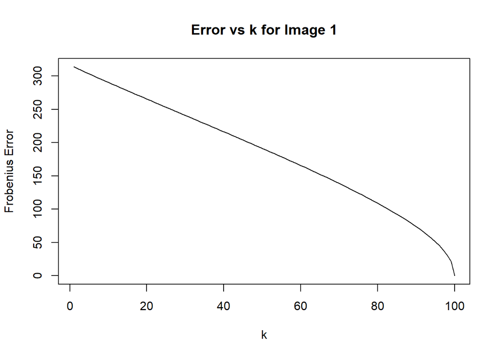

```r
errors <- numeric()

for (k in 1:ncol(x1)) {
  errors[k] <- compress_image_eigen(x1, k)$error
}
plot(errors, type = "l",
     xlab = "k", ylab = "Frobenius Error",
     main = "Error vs k for Image 1")
```

### 1.5 First Eigenvector Plot and First PC Score Plot

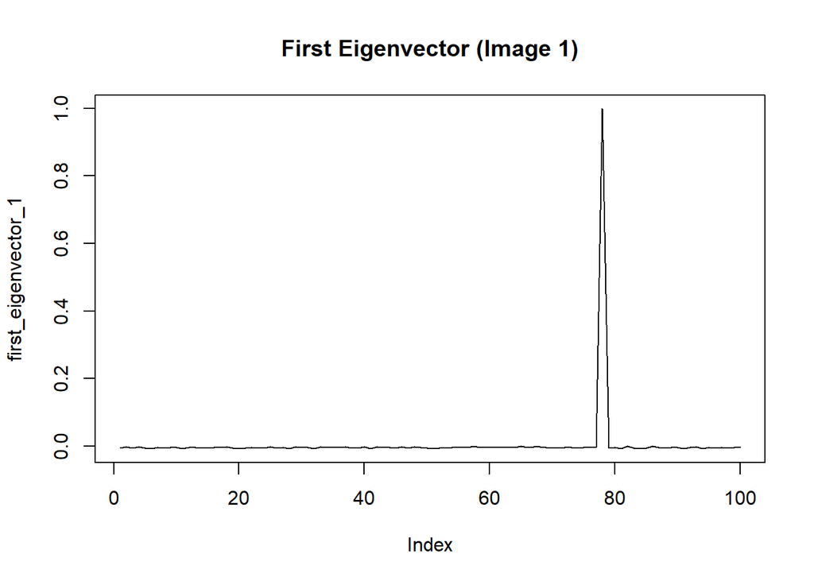

```r
# Compute X'X
V1 <- t(x1) %*% x1

# Eigendecomposition
eig1 <- eigen(V1)

# First eigenvector
first_eigenvector_1 <- eig1$vectors[,1]

# First PC score
first_pc_score_1 <- x1 %*% eig1$vectors[,1]

plot(first_eigenvector_1, type = "l", main = "First Eigenvector (Image 1)")
```

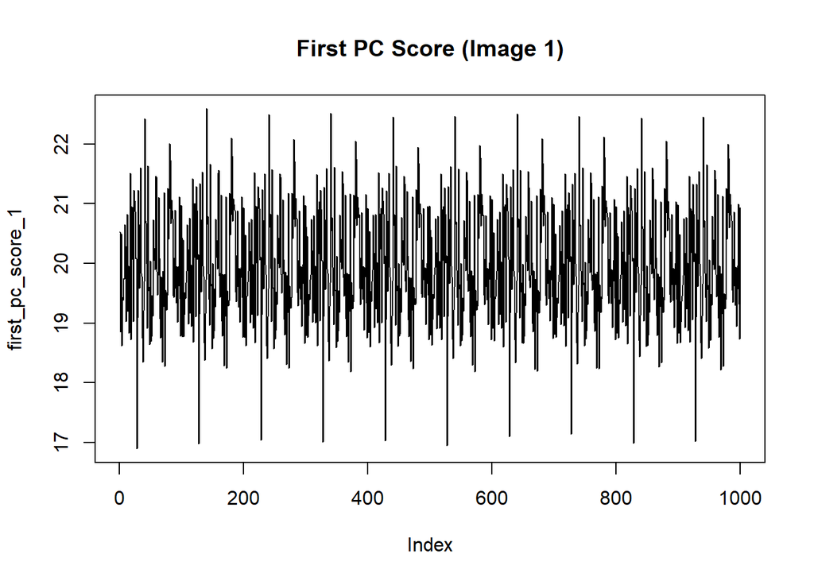

```r
plot(first_pc_score_1, type = "l", main = "First PC Score (Image 1)")
```

**Interpretation of Plots**

The first eigenvector plot shows one dominant peak, meaning most columns contribute very little except that narrow region, which defines the main structure of the image. The first PC score plot fluctuates across rows, because the presence of the horizontal line makes those particular rows different from the rest of the image. Together, these plots show that the image’s structure is dominated by that horizontal line, so small k PCA captures the broad line while larger k values preserve finer shading and detail.

### 1.6 My chosen sufficiently good value of k

For Image 1, the main structure is a single horizontal line against a lightly textured background. The error vs k plot shows the Frobenius error decreases steadily, which indicates that the image’s variance is distributed gradually across components. Because the curve does not reveal a clear turning point, visual inspection of the PCA Approximations is essential for selecting a sufficiently good value of k. The PCA Approximations for k = 1 to 10 show that this dominant line is already captured at very small values of k, around k = 6, and the background remains smooth without distortion. Because the image is simple, the first few components (roughly PC1 to PC6) already capture most of its structure, and adding more components only refines minor background details without significantly improving visual quality. Therefore, k = 6 is a sufficiently good choice for this image, balancing visual accuracy with efficient compression.

## 2. Image 2 Analysis

### 2.1 Load Image

```r
library(readr)
x2 <- read_csv("image2.csv")
x2 <- data.matrix(x2)
```

### 2.2 Original Image

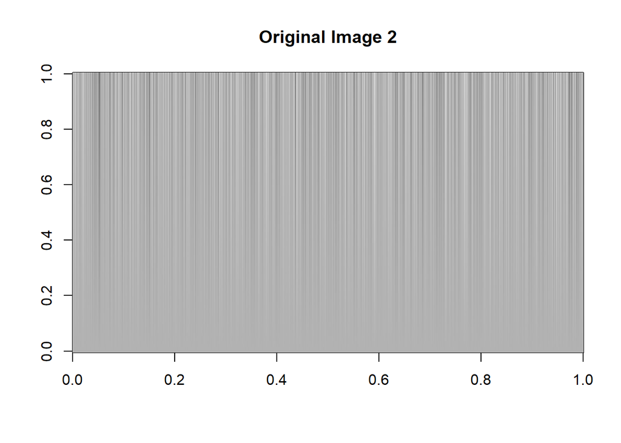

```r
image(x2, col = gray.colors(256), main = "Original Image 2")
```

### 2.3 PCA Approximations (k = 1 to 10)

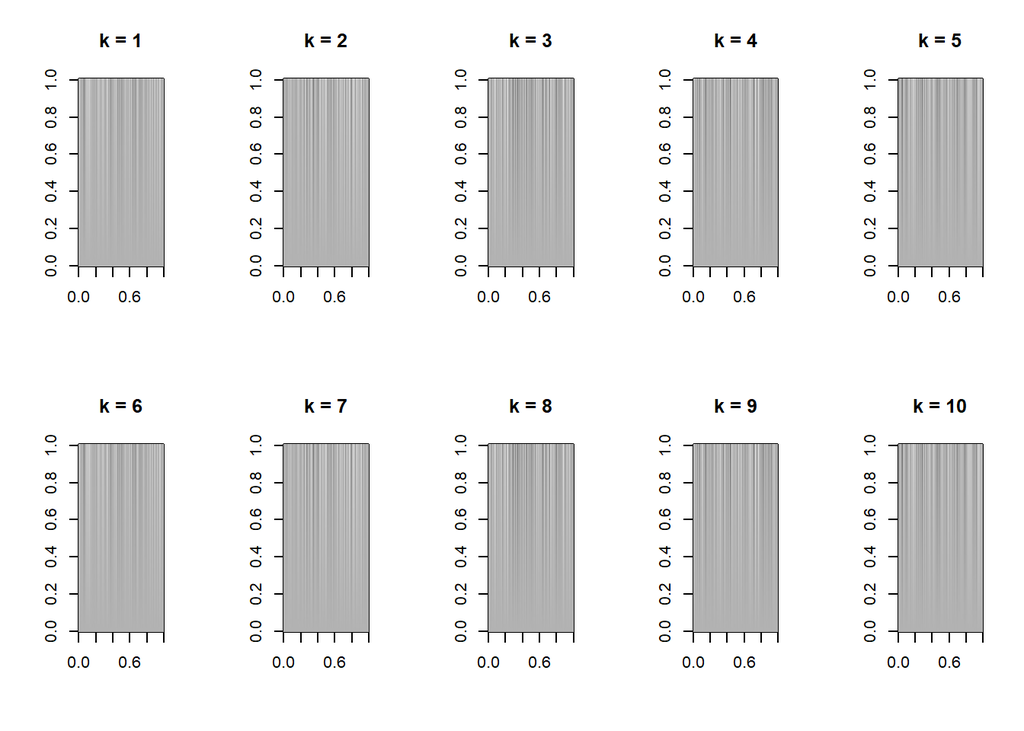

```r
par(mfrow = c(2,5))
for (k in 1:10) {
  result <- compress_image_eigen(x2, k)
  image(result$approx, col = gray.colors(256),
        main = paste("k =", k))
}
```

```r
par(mfrow = c(1,1))
```

### 2.4 A plot of the approximation error vs. k for all possible values of k

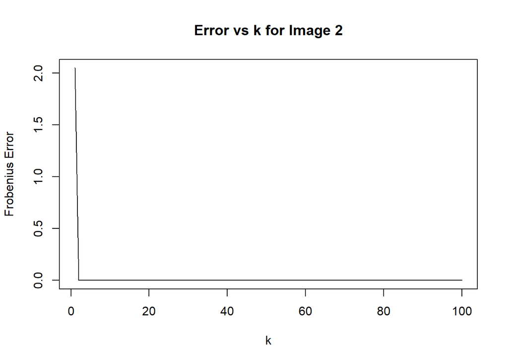

```r
errors <- numeric()

for (k in 1:ncol(x2)) {
  errors[k] <- compress_image_eigen(x2, k)$error
}

plot(errors, type = "l",
     xlab = "k", ylab = "Frobenius Error",
     main = "Error vs k for Image 2")
```